# Introduction to R

Summer Training as Research Scholar

July 9, 2019

### R as a scientific calculator

```r
2 + 3    # addition
```

```
[1] 5
```

```r
2 ^ 3    # power
```

```
[1] 8
```

```r
log(2)   # built-in functions
```

```
[1] 0.6931472
```

### R variables

```r
a <- 3
b = -5  # both assignment operators are equivalent, the first one is more traditional
A <- 7  # R is case sensitive
```

Avoid using names c, t, cat, F, T, D as those are built-in functions/constants

The variable name can contain letters, digits, underscores and dots and start with the letter or dot.  
The variable name cannot contain dollar sign or other special characters.

```r
str.var  <- "oxygen"               # character variable
num.var  <- 15.99                  # numerical variable
bool.var <- TRUE                   # boolean (or logical) variable
bool.var.1 <- F                    # logical values can be abbriviated
```

### R help

```r
# Access help file for the R function if the name of the function is known
?sd
help(sd)


# Search for help
??"standard deviation"
help.search("standard deviation")
help.search("analysis of variance")
```

### R vectors

Vector is an array of values of the same type: Vectors can be numeric, character or logical.

```r
# Function c() is used to create a vector from a list of values
num.vector <- c( 5, 7, 9, 11, 4, -1, 0)

# Numeric vectors can be defined in a number of ways:
vals1 <- c (2, -7, 5, 3, -1 )             # concatenation
vals2 <- 25:75                            # range of values
vals3 <- seq(from=0, to=3, by=0.5)        # sequence definition
vals4 <- rep(1, times=7)                  # repeat value
vals5 <- rnorm(5, mean=2, sd=1.5 )        # normally distributed values

# view the values of the vector
print(vals2)
```

```
 [1] 25 26 27 28 29 30 31 32 33 34 35 36 37 38 39 40 41 42 43 44 45 46 47
[24] 48 49 50 51 52 53 54 55 56 57 58 59 60 61 62 63 64 65 66 67 68 69 70
[47] 71 72 73 74 75
```

### Vector operations in R

```r
# Define 2 vectors ( first with "distance" values and one with "time valuse")
dist <- c(6, 10, 5, 8, 15, 9)
time <- c(0.5, 0.9, 0.4, 0.7, 1.2, 0.85)

# Compute velocity values for each dist-time pair:
velocity <- dist/time   # each element of the first vector will be divided by the element from the second vector with the same index
print(velocity)
```

```
[1] 12.00000 11.11111 12.50000 11.42857 12.50000 10.58824
```

```r
# Define a vector with values of body temperature in Fahrenheit
ftemp <- c(97.8, 99.5, 97.9, 102.1, 98.4, 97.7)

# Convert ftem to a vector with values in Celsius
ctemp <- (ftemp - 32) / 9 * 5
print(ctemp)
```

```
[1] 36.55556 37.50000 36.61111 38.94444 36.88889 36.50000
```

### vector slicing (subsetting)

```r
x <- c(36.6, 38.2, 36.4, 37.9, 41.0, 39.9, 36.8, 37.5)    # define a numeric vector
x[2]         # returns second element
```

```
[1] 38.2
```

```r
x[2:4]       # returns second through 4th elements inclusive
```

```
[1] 38.2 36.4 37.9
```

```r
x[c(1,3,5)]  # returns 1st, 3rd and 5th elements
```

```
[1] 36.6 36.4 41.0
```

```r
x[-2]        # returns all but 2nd element
```

```
[1] 36.6 36.4 37.9 41.0 39.9 36.8 37.5
```

```r
x[c(TRUE, FALSE, TRUE, FALSE, FALSE,FALSE, TRUE, FALSE)]   # returns 1st, 3rd, and 7th elements
```

```
[1] 36.6 36.4 36.8
```

```r
#compare each element of the vector with a value
x < 37.0
```

```
[1]  TRUE FALSE  TRUE FALSE FALSE FALSE  TRUE FALSE
```

```r
#return only those elements of the vector that satisfy a specific condition
x[ x < 37.0 ]
```

```
[1] 36.6 36.4 36.8
```

There are a number of functions that are useful to locate a value satidfying specific condition(s)

```r
which.max(x)  # find the (first)maximum element and return its index
```

```
[1] 5
```

```r
which.min(x)
```

```
[1] 3
```

```r
which(x >= 37.0) # find the location of all the elements that satisfy a specific condition
```

```
[1] 2 4 5 6 8
```

### vector functions:

```
               max(x),   min(x),   sum(x)
               mean(x),  sd(), median(x),  range(x)
               var(x)                            - simple variance
               cor(x,y)                          - correlation between x and y
               sort(x), rank(x), order(x)        - sorting
               duplicated(x), unique(x)          - unique and repeating values
               summary()
```

### Missing Values

```r
x <- c(734, 145, NA, 456, NA)    # define a numeric vector
anyNA(x)              # are there any missing data
```

```
[1] TRUE
```

To check which values are missing use *is.na()* function:

```r
x == NA               # this does not work ! - missing value cannot be compared to anything
```

```
[1] NA NA NA NA NA
```

```r
is.na(x)              # check if the element in the vector is missing
```

```
[1] FALSE FALSE  TRUE FALSE  TRUE
```

```r
which(is.na(x))       # which elements are missing
```

```
[1] 3 5
```

By default statistical functions will not compute if the data contain missing values:

```r
mean(x)
```

```
[1] NA
```

To view the arguments that need to be used to remove missing data, read help topic for the function:

```r
?mean
```

```r
#Perform computation removing missing data
mean(x, na.rm=TRUE)
```

```
[1] 445
```

### R packages

```r
#To install package
install.packages("foreign")
```

Once package is installed it can be loaded and used:

```r
#Load R package
library(foreign)
```

### Reading input files

There are many R functions to process files with various formats: Some come from base R:

- read.table()
- read.csv()
- read.delim()
- read.fwf()
- scan() and many others

There are a few R packages which provide additional functionality to read files.

```r
#Load R package "foreign"
library(foreign)

# Read data in Stata format
swissdata <- read.dta("http://rcs.bu.edu/classes/STaRS/swissfile.dta")

# Load R package sas7bdat (make sure it is installed! )
library(sas7bdat)

# Read data in SAS format
fhsdata <- read.sas7bdat( "http://rcs.bu.edu/classes/STaRS/fhs.sas7bdat" )
```

### Exploring R dataframes

```r
# Read regular csv file:
salt <- read.csv("http://rcs.bu.edu/classes/STaRS/intersalt.csv")
```

This data contains median blood pressure, as a fuction of salt intake:

- b - numeric vector
- bp - mean diastolic blood pressure (mm Hg)
- sodium - mean sodium excretion (mmol/24h)
- country

```r
#Look at the first and last few records
head(salt)
```

```
      b   bp sodium   country
1 0.512 72.0  149.3 Argentina
2 0.226 78.2  133.0   Belgium
3 0.316 73.9  142.6   Belgium
4 0.042 61.7    5.8    Brazil
5 0.086 61.4    0.2    Brazil
6 0.265 73.4  148.9    Canada
```

```r
tail(salt)
```

```
       b   bp sodium      country
47 0.434 73.2  130.3       Hawaii
48 0.295 81.4  136.6      USBlack
49 0.204 76.2  133.4           US
50 0.300 74.7  162.0 West Germany
51 0.303 73.1  172.0 West Germany
52 0.360 75.6  129.7     Zimbabwe
```

```r
#Get the list of the columns
names(salt)
```

```
[1] "b"       "bp"      "sodium"  "country"
```

```r
#Number of rows:
nrow(salt)
```

```
[1] 52
```

```r
#Number of columns:
ncol(salt)
```

```
[1] 4
```

```r
#Get the structure of the data:
str(salt)
```

```
'data.frame':   52 obs. of  4 variables:
 $ b      : num  0.512 0.226 0.316 0.042 0.086 0.265 0.384 0.501 0.352 0.443 ...
 $ bp     : num  72 78.2 73.9 61.7 61.4 73.4 79.2 66.6 82.1 75 ...
 $ sodium : num  149.3 133 142.6 5.8 0.2 ...
 $ country: Factor w/ 32 levels "Argentina","Belgium",..: 1 2 2 3 3 4 4 5 6 7 ...
```

```r
#Get the summary of the data:
summary(salt)
```

```
       b                bp            sodium         country
 Min.   :0.0420   Min.   :61.40   Min.   :  0.2   Italy  : 4
 1st Qu.:0.2930   1st Qu.:70.58   1st Qu.:135.0   Japan  : 3
 Median :0.3460   Median :73.15   Median :152.5   PRC    : 3
 Mean   :0.3502   Mean   :73.15   Mean   :148.3   UK     : 3
 3rd Qu.:0.4422   3rd Qu.:76.45   3rd Qu.:172.7   US     : 3
 Max.   :0.6790   Max.   :82.10   Max.   :242.1   Belgium: 2
                                                  (Other):34
```

# Numeric data exploratory analysis

```r
min(salt$bp)
```

```
[1] 61.4
```

```r
max(salt$bp)
```

```
[1] 82.1
```

```r
range(salt$bp)
```

```
[1] 61.4 82.1
```

```r
summary(salt$bp)
```

```
   Min. 1st Qu.  Median    Mean 3rd Qu.    Max.
  61.40   70.58   73.15   73.15   76.45   82.10
```

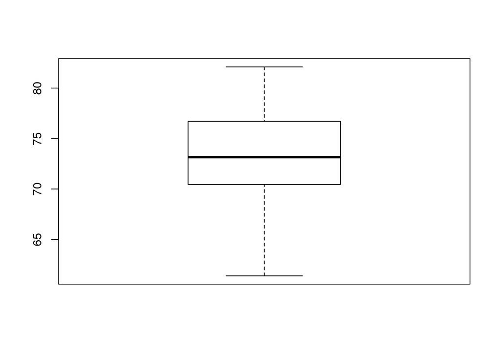

```r
#Sometimes it is helpful to visualize the data
boxplot( salt$bp  )
```

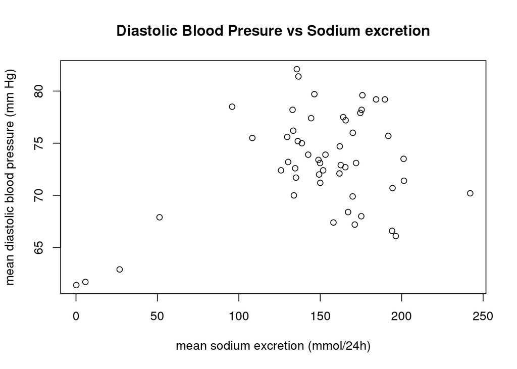

```r
plot(x = salt$sodium,
     y = salt$bp,
     xlab = "mean sodium excretion (mmol/24h)",
     ylab = "mean diastolic blood pressure (mm Hg)",
     main = "Diastolic Blood Presure vs Sodium excretion")
```

### Correlation

This test is used to test the linear relationship of 2 continious variables

```r
cor.test(salt$bp, salt$sodium)
```

```
    Pearson's product-moment correlation

data:  salt$bp and salt$sodium
t = 2.7223, df = 50, p-value = 0.008901
alternative hypothesis: true correlation is not equal to 0
95 percent confidence interval:
 0.09577287 0.57573339
sample estimates:
      cor
0.3592828
```

The **Null Hypothesis** : the true correlation between bp and sodium (blood pressure and salt intake) is 0 (they are independent);  
The **Alternative hypothesis**: true correlation between bp and sodium is not equal to 0.

The *p-value* is less that 0.05 and the 95% CI does not contain 0, so at the significance level of 0.05 we reject null hypothesis and state that there is some (positive) correlation (0.359) between these 2 variables.

```
*  0 < |r| < .3 - weak correlation
* .3 < |r| < .7 - moderate correlation
*      |r| > .7 - strong correlation
```

**Important**:

- The order of the variables in the test is not important
- Correlation provide evidence of association, not causation!
- Correlation values is always between -1 and 1 and does not change if the units of either or both variables change
- Correlation describes *linear* relationship
- Correlation is strongly affected by outliers (extreme observations)

### Linear Model

```r
lm.res <- lm( bp ~ sodium, data = salt)
summary(lm.res)
```

```
Call:
lm(formula = bp ~ sodium, data = salt)

Residuals:
    Min      1Q  Median      3Q     Max
-8.8625 -2.8906  0.0299  3.6470  9.4283

Coefficients:
            Estimate Std. Error t value Pr(>|t|)
(Intercept) 67.56245    2.14643  31.477   <2e-16 ***
sodium       0.03768    0.01384   2.722   0.0089 **
---
Signif. codes:  0 '***' 0.001 '**' 0.01 '*' 0.05 '.' 0.1 ' ' 1

Residual standard error: 4.511 on 50 degrees of freedom
Multiple R-squared:  0.1291,    Adjusted R-squared:  0.1117
F-statistic: 7.411 on 1 and 50 DF,  p-value: 0.008901
```

Here we estimated that relationship between the predictor (*sodium*) and response (*bp*) variables.  
The summary statistics here reports a number of things. *p-value* tells us if the model is statistically significant. In Linear Regression, the Null Hypothesis is that the coefficient associated with the variables are equal to zero.  
Multiple R-squared value is equal to the square of the correlation value we calculated in the previous test.

When the model fits the data;

- **R-squared** - The higher - the better ( > 0.7)
- **F-statistics** - The higher the better
- **Std. Error** - The closer to 0 - the better
- **t-statistics** - Should be 1.96 for 0.05 significance level

### Shapiro test

This test is used to check if the sample follows a normal distribution

```r
shapiro.test(salt$sodium)
```

```
    Shapiro-Wilk normality test

data:  salt$sodium
W = 0.84629, p-value = 8.758e-06
```

The **null hypothesis**: sample being tested is normally distributed.  
*p value* for this test is very small (8.758e-06), so we can reject the null hypothesis and state that this sample does not follow a normal distribution.  
Let’s now take a look at the variable bp:

```r
shapiro.test(salt$bp)
```

```
    Shapiro-Wilk normality test

data:  salt$bp
W = 0.97341, p-value = 0.2932
```

Here the *p value* is greater than 0.05 and at the significance level of 0.05 we cannot reject the null hypothesis.

### One Sample t-Test

This test is used to test the mean of a sample from a normal distribution

```r
t.test(salt$bp, mu=70)
```

```
    One Sample t-test

data:  salt$bp
t = 4.7485, df = 51, p-value = 1.703e-05
alternative hypothesis: true mean is not equal to 70
95 percent confidence interval:
 71.81934 74.48451
sample estimates:
mean of x
 73.15192
```

The **null hypothesis**: The true mean is equal to 70  
The **alternative hypothesis**: true mean is not equal to 70  
Since *p-value* is small (1.703e-05) - less than 0.05, 95% percent CI does not contain the value 70, we can reject the NULL hypothesis.

### Two Sample t-TEST

Let’s load some other dataset. It comes with R. This dataset shows the effect of two soporific drugs (increase in hours of sleep compared to control) on 10 patients. There are 3 variables:

- **extra**: (numeric) increase in hours of sleep
- **group**: (factor) categorical variable indicating which drug is given
- **ID**: (factor) patient ID

```r
data(sleep)
head(sleep)
```

```
  extra group ID
1   0.7     1  1
2  -1.6     1  2
3  -0.2     1  3
4  -1.2     1  4
5  -0.1     1  5
6   3.4     1  6
```

```r
summary(sleep)
```

```
     extra        group        ID
 Min.   :-1.600   1:10   1      :2
 1st Qu.:-0.025   2:10   2      :2
 Median : 0.950          3      :2
 Mean   : 1.540          4      :2
 3rd Qu.: 3.400          5      :2
 Max.   : 5.500          6      :2
                         (Other):8
```

To compare the means of 2 samples:

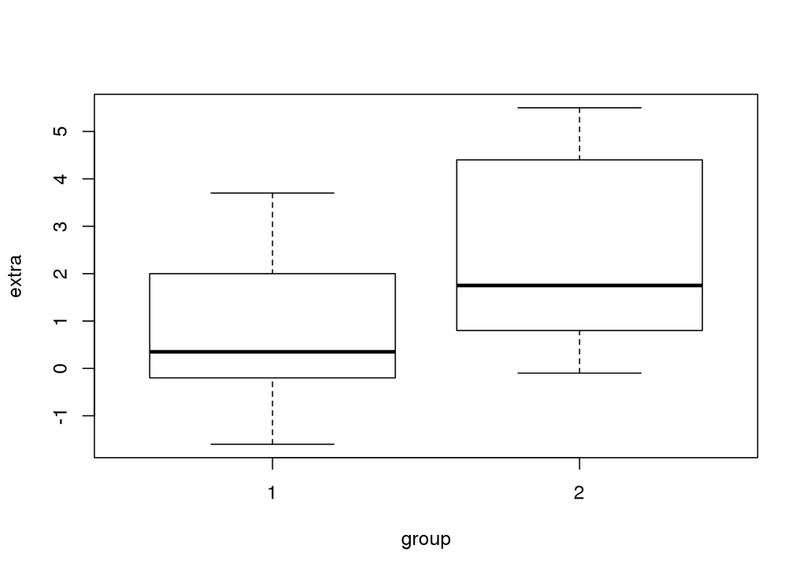

```r
boxplot(extra ~ group, data = sleep)
```

```r
t.test(extra ~ group, data = sleep)
```

```
    Welch Two Sample t-test

data:  extra by group
t = -1.8608, df = 17.776, p-value = 0.07939
alternative hypothesis: true difference in means is not equal to 0
95 percent confidence interval:
 -3.3654832  0.2054832
sample estimates:
mean in group 1 mean in group 2
           0.75            2.33
```

Here the **Null Hypothesis** is that the true difference between 2 groups is equal to 0  
And **Alternative Hypothesis** is that it does not equal to 0 In this test the p-value is above significance level of 0.05 and 95% CI contains 0, so we cannot reject the NULL hypothesis.

Note, that t.test has a number of options, including *alternative* which can be set to “two.sided”, “less”, “greater”, depending which test you would like to perform. Using option *var.equal* you can also specify if the variances of the values in each group are equal or not.

### One-way ANOVA test

The one-way analysis of variance (**ANOVA**) test is an extension of two-samples t.test for comparing means for datasets with more than 2 groups.

**Assumptions**:

- The observations are obtained independently and randomly from the population defined by the categorical variable
- The data of each category is normally distributed
- The populations have a common variance.

```r
data("PlantGrowth")
head(PlantGrowth)
```

```
  weight group
1   4.17  ctrl
2   5.58  ctrl
3   5.18  ctrl
4   6.11  ctrl
5   4.50  ctrl
6   4.61  ctrl
```

```r
summary(PlantGrowth)
```

```
     weight       group
 Min.   :3.590   ctrl:10
 1st Qu.:4.550   trt1:10
 Median :5.155   trt2:10
 Mean   :5.073
 3rd Qu.:5.530
 Max.   :6.310
```

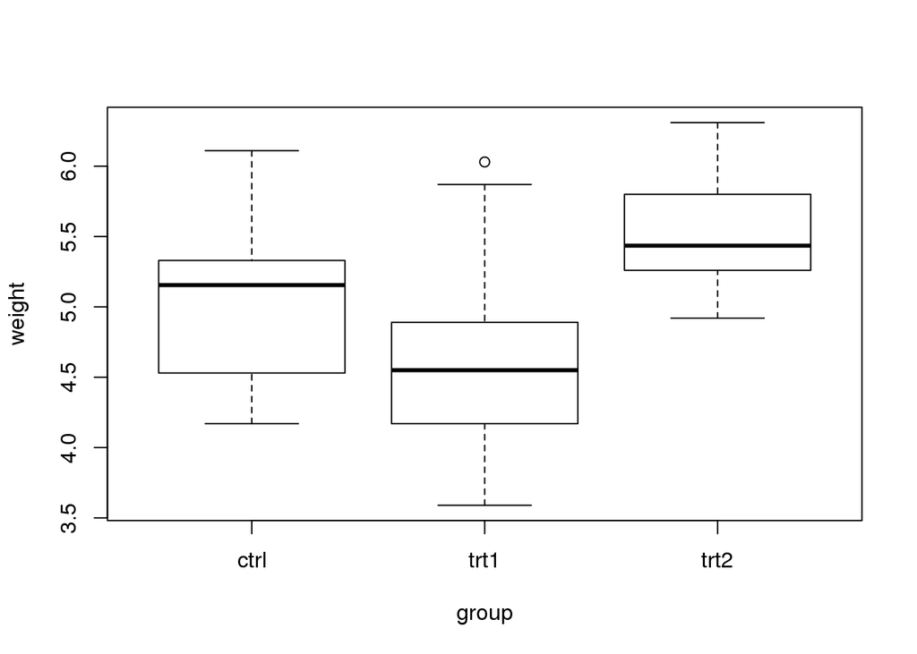

```r
boxplot(weight~group, data=PlantGrowth)
```

As visible from the side-by-side boxplots, there is some difference in the weights of 3 groups, but we cannot determine from the plot if this difference is significant.

```r
aov.res <- aov(weight~group, data=PlantGrowth)
summary( aov.res )
```

```
            Df Sum Sq Mean Sq F value Pr(>F)
group        2  3.766  1.8832   4.846 0.0159 *
Residuals   27 10.492  0.3886
---
Signif. codes:  0 '***' 0.001 '**' 0.01 '*' 0.05 '.' 0.1 ' ' 1
```

As we can see from the summary output the *p-value* is 0.0159 < 0.05 which indicates that there is a statistically significant difference in weignt between these groups. We can check the confidence intervals for the treatment parameters:

```r
confint(aov.res)
```

```
                  2.5 %    97.5 %
(Intercept)  4.62752600 5.4364740
grouptrt1   -0.94301261 0.2010126
grouptrt2   -0.07801261 1.0660126
```

**Important**: In one-way ANOVA testsa small p-value indicates that some of the group means are different, but it does not say which ones!

For multiple pairwise-comparisions we use **Tukey** test:

```r
TukeyHSD(aov.res)
```

```
  Tukey multiple comparisons of means
    95% family-wise confidence level

Fit: aov(formula = weight ~ group, data = PlantGrowth)

$group
            diff        lwr       upr     p adj
trt1-ctrl -0.371 -1.0622161 0.3202161 0.3908711
trt2-ctrl  0.494 -0.1972161 1.1852161 0.1979960
trt2-trt1  0.865  0.1737839 1.5562161 0.0120064
```

This result indicates that the significant difference in between treatment 1 and treatment 2 with the adjusted *p-value* of 0.012.

# Chategorical Variables:

### Chi-Squred test of independence in R

The chi-square test is used to analyze the frequency table ( or contengency table) formed by two categorical variables. It evaluates whether there is a significant association between the categories of the two variables.

```r
treat <- read.csv("http://rcs.bu.edu/classes/STaRS/treatment.csv")
head(treat)
```

```
  id treated improved
1  1       1        1
2  2       1        1
3  3       0        1
4  4       1        1
5  5       1        0
6  6       1        0
```

```r
summary(treat)
```

```
       id         treated          improved
 Min.   :  1   Min.   :0.0000   Min.   :0.000
 1st Qu.: 27   1st Qu.:0.0000   1st Qu.:0.000
 Median : 53   Median :0.0000   Median :1.000
 Mean   : 53   Mean   :0.4762   Mean   :0.581
 3rd Qu.: 79   3rd Qu.:1.0000   3rd Qu.:1.000
 Max.   :105   Max.   :1.0000   Max.   :1.000
```

In the above dataset there are 2 categorical variables:

- treated - 0 or 1
- improved - 0 or 1

We would like to test if there is an improvement after the treatment. In other words if these 2 categorical variables are dependent.

First let’s take a look at the tables:

```r
# Frequency table: "treated will be rows, "improved" - columns"
table(treat$treated, treat$improved)
```

```
     0  1
  0 29 26
  1 15 35
```

```r
# Proportion table
prop.table(table(treat$treated, treat$improved))
```

```
            0         1
  0 0.2761905 0.2476190
  1 0.1428571 0.3333333
```

We can visualize this contingency table with a mosaic plot:

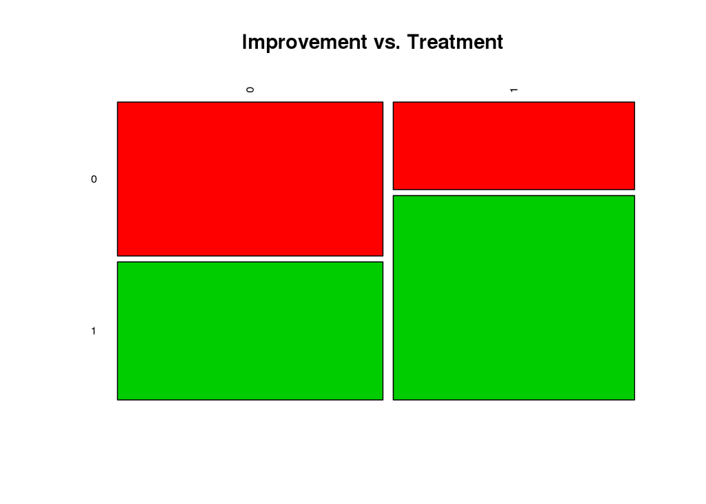

```r
tbl <- table(treat$treated, treat$improved)
mosaicplot( tbl, color = 2:3, las = 2, main = "Improvement vs. Treatment" )
```

Compute chi-squred test

```r
chisq.test (tbl)
```

```
    Pearson's Chi-squared test with Yates' continuity correction

data:  tbl
X-squared = 4.6626, df = 1, p-value = 0.03083
```

The **Null Hypothesis** is that *treated* and *improved* variables are independent.  
In the above test the *p-value* is 0.03083, so at the significance level of 0.05 we can reject the null hypothesis